# Data Visualization

## Stats 141B

## Lecture 13

## Prof. Sharpnack

## Lecture slides at http://anson.ucdavis.edu/~jsharpna/141Blectures/

## Lecture repository at https://github.com/jsharpna/141Blectures/

## Data Visualization

### Old way

- Named plots:
  - histogram, scatterplot, time series plot, etc.
- Increasingly complicated named plots (e.g. Hexbin plot with marginal distributions)
- Lacks versitility: many options as you build a plot, a named plot can only give you so many options

### New way

- Deconstructing the plot: understand and name the components
- Grammar of graphics: rules that guide how these fit together

## Graphical excellence

- shows the data
- induce the viewer to think about substance rather than methodology
- avoid distortion of data
- present many numbers in small space
- make large datasets coherent
- encourage the eye to compare different pieces of data
- reveal the data at several levels of detail
- serve a reasonably clear purpose: description, exploration, tabulation, or decoration
- be closely integrated with the statistical and verbal descriptions of a data set

(The Visual Display of Quantitative Info., Tufte)

[figure not shown]

- Caption translated to English: "The numbers of men present are represented by the widths of the colored zones at a rate of one millimeter for every ten thousand men; they are further written across the zones. The [tan] designates the men who enter Russia, the black those who leave it."
- Original image of Minard's graphic from John Schneider's Napoleonic Literature page, linked on http://www.datavis.ca/gallery/re-minard.php

[figure not shown]

- Powerpoint reproduction from http://extremepresentation.typepad.com/blog/2010/06/

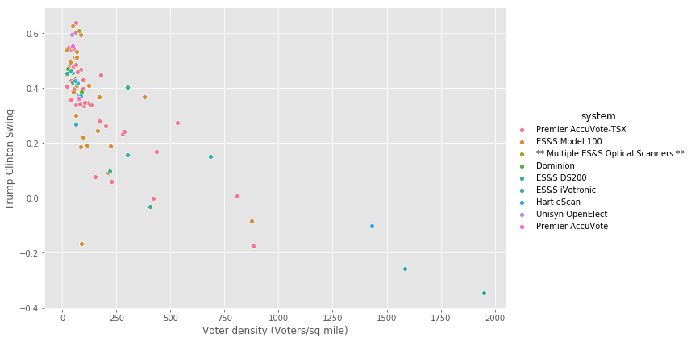

```python
sns.pairplot(x_vars=['voter_density'], y_vars=['swing'], data=OH_counties, hue='system',height=6,aspect=1.5)
plt.xlabel('Voter density (Voters/sq mile)')
plt.ylabel('Trump-Clinton Swing')
plt.show()
```

## Deconstructing this plot

### Elements of the plot

- geometric objects (geoms): points
- coordinate systems: linear scale and Euclidean coordinates
- annotation for the plot: labels, legend

### Aesthetic mappings

- aesthetic elements: X-position, Y-position, color
- aesthetic mappings: function mapping variable to aesthetic element

### Example aesthetic mapping

Linear map from Series, x, to [0,1]. $$ f(x) = \frac{x - x.min()}{x.max() - x.min()} $$ Mapping is appropriate for position.

### Scale

A scale is a function applied to the variable before/during the aethetic mapping, $$ g(x) = \log(x), $$ so that final map is $f(g(x))$.

### Why not just let the user make their own mappings?

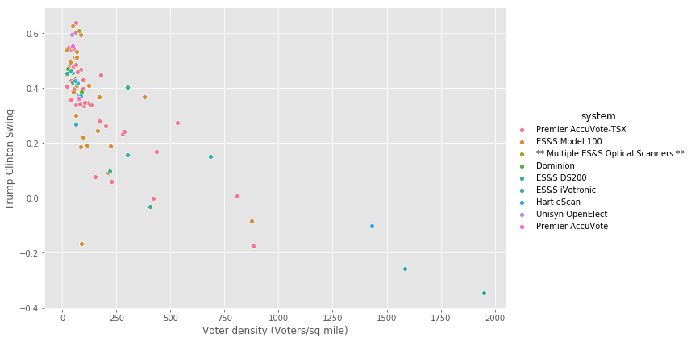

```python
sns.pairplot(x_vars=['voter_density'], y_vars=['swing'], data=OH_counties, hue='system',height=6,aspect=1.5)
plt.xlabel('Voter density (Voters/sq mile)')
plt.ylabel('Trump-Clinton Swing')
plt.show()
```

### Aesthetic mappings

- `voter_density` mapped to X-position
- `swing` mapped to Y-position
- `system` mapped to color

## Matplotlib

- Figure: the entire drawing canvas
- Axes: each plot with all geometric objects, coordinate systems, annotations
- Artists: geometric objects (polygons, points, etc.)

[figure not shown]

*matplotlib.org

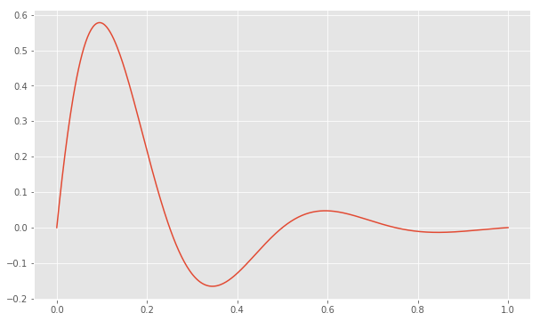

```python
## Example from book

## Create data
x = np.linspace(0, 1, 500)
y = np.sin(4 * np.pi * x) * np.exp(-5 * x)

plt.plot(x, y) # plot with Pyplot
plt.show() # show the figure
```

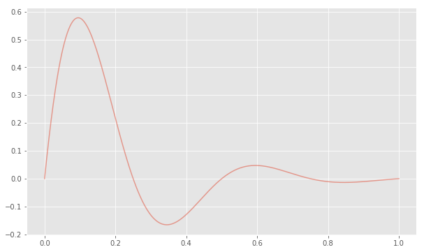

```python
plt.plot(x, y)

fig = plt.gcf() # get current figure
ax, = fig.axes # get axes for that figure
li = ax.lines[0] # get line (inherited from Artist)
li.set_alpha(.5) # set alpha for that line

plt.show()
```

```python
## The types of these objects

type(fig), type(ax), type(li)
```

```
(matplotlib.figure.Figure,
 matplotlib.axes._subplots.AxesSubplot,
 matplotlib.lines.Line2D)
```

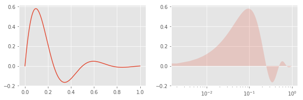

```python
## Example from book
## It looks different because of plt.style.use('ggplot')

fig, ax = plt.subplots(1,2,figsize=(10,3))

ax[0].plot(x,y) # plot on the first axis

patches = ax[1].fill(x, y) # fill on the second
pat = patches[0] # isolate the polygon
pat.set_alpha(0.2) # set the alpha - transparency
ax[1].grid(True) # add grid lines
ax[1].set_xscale('log') # set the scale of the x-axis
plt.show()
```

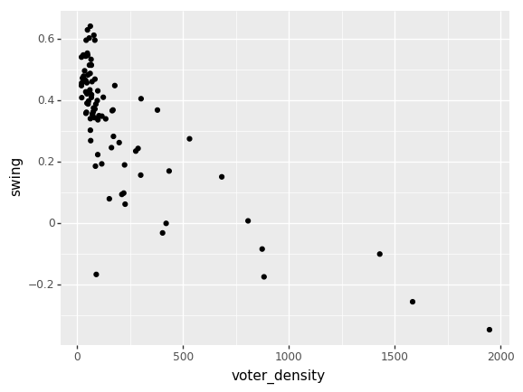

```python
## the same with Plotnine
gg = p9.ggplot(OH_counties) # set data, start default layer
gg += p9.aes(x='voter_density',y='swing') # add aesthetic mappings
gg += p9.geom_point() # add point geom
gg
```

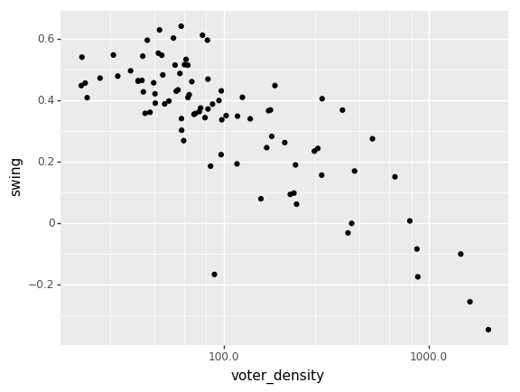

```python
gg = p9.ggplot(OH_counties)
gg += p9.aes(x='voter_density',y='swing')
gg += p9.geom_point()
gg += p9.scale_x_log10() # add log scale to X mapping
gg
```

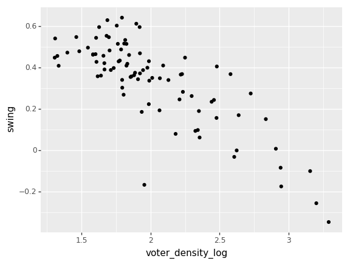

```python
## make transformation first
OH_counties['voter_density_log'] = np.log10(OH_counties['voter_density'])
gg = p9.ggplot(OH_counties)
gg += p9.aes(x='voter_density_log',y='swing')
gg += p9.geom_point()
gg
```

### Layered grammar of graphics

In addition to basic elements:

- geoms
- aesthetics
- aesthetic mappings

Also have:

- scales, coordinate systems
- layers
- stats
- facetting

### Layers

- contains geoms, statistical transformation, and possibly a position adjustment
- can inherit the dataset and aesthetic mappings from default layer
- overlayed ontop of one another

### Coordinate Systems

- Euclidean coords uses X,Y aesthetics to determine positions
- Radial coords uses radius and angle to determine positions
- Scale can be applied independently of coord

### Stats (statistical transformations)

- take the data as input and outputs new data
- transformation can be dependent on aspects of the current plot (such as scales)
- scale modifies the aesthetic mapping, stats modify a layer (or creates its own layer)

### Facetting

- group by a variable or equation
- creates plots for each subset
- by default stats are applied groupwise

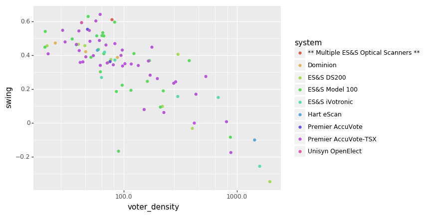

```python
gg = p9.ggplot(OH_counties)
gg += p9.aes(x='voter_density',y='swing',color='system') # add color mapping
gg += p9.geom_point()
gg += p9.scale_x_log10()
gg
```

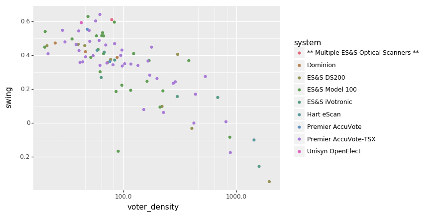

```python
gg += p9.scale_color_hue(color_space='husl') # slightly different color map
gg
```

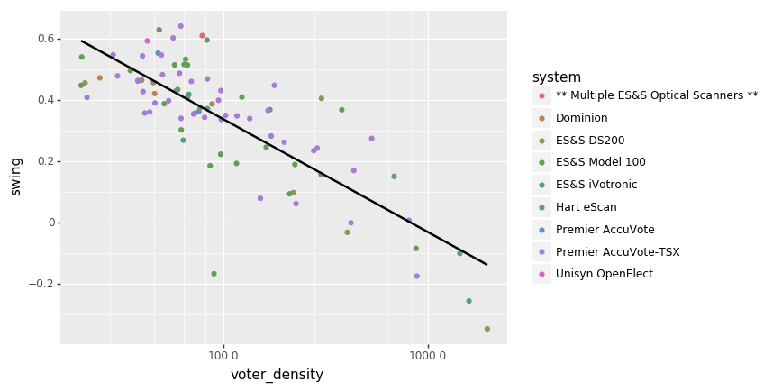

```python
## add linear regression stat
gg + p9.stat_smooth(mapping=p9.aes(x='voter_density',y='swing'),
                 method='lm', se = False, inherit_aes=False)
```

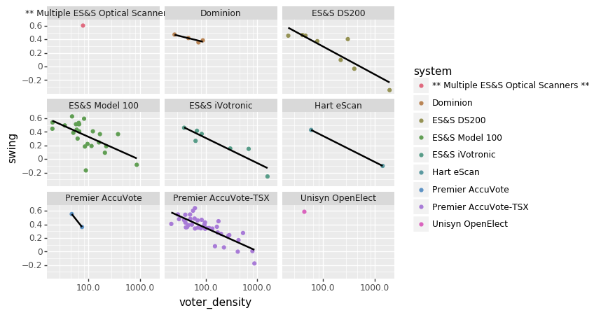

```python
## facet on equation ~system
gg + p9.facet_wrap('~system') \
+ p9.stat_smooth(mapping=p9.aes(x='voter_density',y='swing'),
                 method='lm', se = False, inherit_aes=False)
```

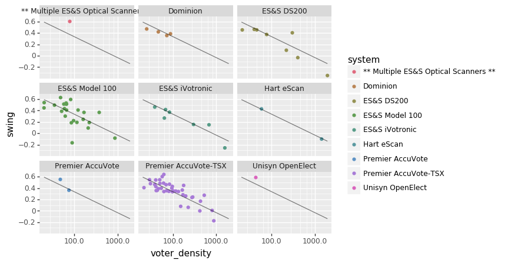

```python
## I want to compare against same regression line
## Use this trick (remove system from data)

gg + p9.facet_wrap('~system') \
+ p9.geom_line(stat='smooth',method='lm',mapping=p9.aes(x='voter_density',y='swing'),
                 data=OH_counties[['voter_density','swing']],
                 se = False, inherit_aes=False,alpha=.5)
```

[figure not shown]